# Web Scraping

### a very practical introduction

## Why web scraping

- it's free
- data only available on web site
- scraping faster than other APIs
- delayed pubication in other APIs

## Is it reliable

- surprisingly so, if done well

## How can we scrape in python

- depends on the web page and/or what you want to achieve
- inspect source/elements, use eg FireBug
- old school - urllib2, mechanize, requests + lxml, BeautifulSoup
- new school - it depends
- use cookies
- wrap javascript
- webdriver - here we will see selenium

## Practical examples

### Here is an old-school page

```python
from IPython.display import HTML
HTML('<iframe src=http://www.epexspot.com/en/market-data/dayaheadauction width=1060 height=550></iframe>')
```

[interactive chart not shown]

```python
from bs4 import BeautifulSoup
import urllib2
from datetime import datetime

scrape_date = datetime(2015, 2, 24)
url = r'http://www.epexspot.com/en/market-data/dayaheadauction/auction-table/'+scrape_date.strftime("%Y-%m-%d")
html = urllib2.urlopen(url).read()
```

```python
soup = BeautifulSoup(html)
div = soup('div', {'id': 'tab_fr'})[0]
listhours = div('table', {'class': 'list hours responsive'})[0]

columns = ['Hours', 'Units']+[h.string for h in listhours('th')][2:]
data = []
for row in listhours('tr'):
    tds = row('td')
    data.append([e.string.strip().replace(',','') for e in tds])
```

```python
import pandas as pd

res = pd.DataFrame(data, columns=columns, dtype=float).dropna(axis=0)
res.replace(u'\u20ac/MWh','EUR/MWh', inplace=True)
res.set_index('Hours', inplace=True)
res.head()
```

| Hours | Units | Tue, 02/24 | Wed, 02/25 | Thu, 02/26 | Fri, 02/27 | Sat, 02/28 | Sun, 03/01 | Mon, 03/02 |
| --- | --- | --- | --- | --- | --- | --- | --- | --- |
| 00 - 01 | EUR/MWh | 43.19 | 45.93 | 46.43 | 44.98 | 54.10 | 35.62 | 25.00 |
|  | MWh | 7965.30 | 6880.50 | 7323.50 | 8413.40 | 8372.30 | 6929.40 | 8419.20 |
| 01 - 02 | EUR/MWh | 38.62 | 39.92 | 42.92 | 39.29 | 50.95 | 30.90 | 20.36 |
|  | MWh | 8259.70 | 7111.50 | 7154.10 | 7433.80 | 8930.60 | 6907.20 | 8143.60 |
| 02 - 03 | EUR/MWh | 37.93 | 39.50 | 41.96 | 39.38 | 48.78 | 26.70 | 16.62 |

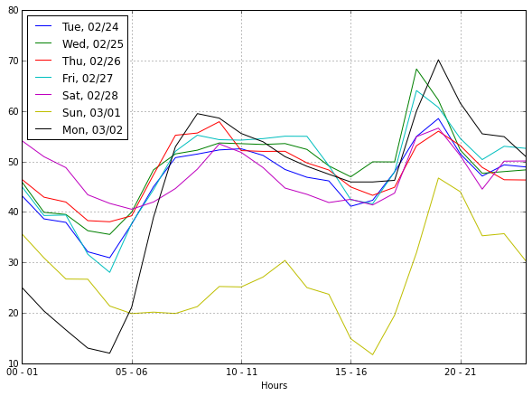

```python
res[res.Units == 'EUR/MWh'].plot(figsize=(10,7));
```

## An even older-school page

### NOAA satelite data

```python
from IPython.display import HTML
HTML('<iframe src=http://www.esrl.noaa.gov/psd/cgi-bin/data/composites/printpage.pl width=1060 height=550></iframe>')
```

[interactive chart not shown]

- Need to fill in and submit the form
- mechanize, requests

```python
import requests

ref_date = datetime(2015,2,15)

var = 'Air+Temperature'
level = 'Surface'
monr1 = ref_date.month
dayr1 = ref_date.day
monr2 = ref_date.month
dayr2 = ref_date.day
iyr = ref_date.year
custproj = 'Cylindrical+Equidistant'
```

```python
url = 'http://www.esrl.noaa.gov/psd/cgi-bin/data/composites/comp.day.pl?'
url += 'var={var}&level={level}&iy[1]=&im[1]=&id[1]=&iy[2]=&im[2]=&id[2]=&iy[3]=&im[3]=&id[3]=&iy[4]=&im[4]=&id[4]=&iy[5]=&im[5]=&id[5]=&iy[6]=&im[6]=&id[6]=&iy[7]=&im[7]=&id[7]=&iy[8]=&im[8]=&id[8]=&iy[9]=&im[9]=&id[9]=&iy[10]=&im[10]=&id[10]=&iy[11]=&im[11]=&id[11]=&iy[12]=&im[12]=&id[12]=&iy[13]=&im[13]=&id[13]=&iy[14]=&im[14]=&id[14]=&iy[15]=&im[15]=&id[15]=&iy[16]=&im[16]=&id[16]=&iy[17]=&im[17]=&id[17]=&iy[18]=&im[18]=&id[18]=&iy[19]=&im[19]=&id[19]=&iy[20]=&im[20]=&id[20]=&'
url += 'monr1={monr1}&dayr1={dayr1}&monr2={monr2}&dayr2={dayr2}&iyr[1]={iyr}&'
url += 'filenamein=&plotlabel=&lag=0&labelc=Color&labels=Shaded&type=1&scale=&label=0&cint=&lowr=&highr=&istate=0&'
url += 'proj=Europe&xlat1=&xlat2=&xlon1=&xlon2=&custproj={custproj}&level1=1000mb&level2=10mb'
url = url.format(**locals())
```

```python
r = requests.get(url)
html = r.content
```

```python
filename = 'http://www.esrl.noaa.gov'+html.split('txt')[0].split('href="')[-1]+'txt'
r = requests.get(filename)
data = r.content
```

### Note

requests can fill the form for you if you pass to requests.get a dictionary of field names and values which will result in an equivalent url (but the form above is too big)

```python
import StringIO
buf = StringIO.StringIO(data)
data = pd.read_csv(buf, sep=r'\s+', header=None, skiprows=10)
data.head()
```

|  | 0 | 1 | 2 | 3 | 4 | 5 | 6 | 7 | 8 | 9 | ... | 134 | 135 | 136 | 137 | 138 | 139 | 140 | 141 | 142 | 143 |
| --- | --- | --- | --- | --- | --- | --- | --- | --- | --- | --- | --- | --- | --- | --- | --- | --- | --- | --- | --- | --- | --- |
| 0 | 242.62500 | 242.62500 | 242.62500 | 242.62500 | 242.62500 | 242.62500 | 242.62500 | 242.62500 | 242.62500 | 242.62500 | ... | 242.62500 | 242.62500 | 242.62500 | 242.62500 | 242.62500 | 242.62500 | 242.62500 | 242.62500 | 242.62500 | 242.62500 |
| 1 | 237.97501 | 237.97501 | 237.97499 | 238.02499 | 238.04999 | 238.14999 | 238.22499 | 238.34999 | 238.45000 | 238.60001 | ... | 238.99998 | 238.84999 | 238.67500 | 238.55000 | 238.39999 | 238.29999 | 238.22499 | 238.12498 | 238.05000 | 238.02499 |
| 2 | 234.72499 | 234.95000 | 235.17499 | 235.50000 | 235.87498 | 236.22499 | 236.62500 | 237.00000 | 237.42500 | 237.82500 | ... | 236.04999 | 235.67499 | 235.32498 | 235.04999 | 234.82500 | 234.62500 | 234.52499 | 234.47499 | 234.50000 | 234.59998 |
| 3 | 244.10001 | 244.57498 | 245.00000 | 245.39999 | 245.67499 | 245.89999 | 246.09999 | 246.12498 | 246.02499 | 245.87500 | ... | 237.97499 | 238.52499 | 239.14999 | 239.82500 | 240.47499 | 241.14998 | 241.82500 | 242.42499 | 243.02498 | 243.57500 |
| 4 | 261.50000 | 261.67499 | 261.45001 | 260.92499 | 260.14999 | 259.07501 | 257.79999 | 256.34998 | 254.72498 | 253.04999 | ... | 241.95000 | 244.67499 | 247.50000 | 250.22501 | 252.84999 | 255.22499 | 257.20001 | 258.89999 | 260.14999 | 261.00000 |

5 rows × 144 columns

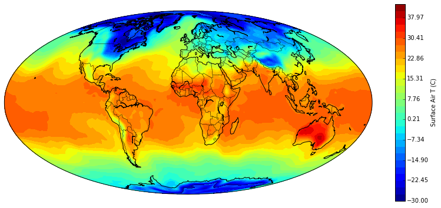

```python
fig = plot_weatherdata(data, 'earth', clevs=clevs, dispmin=242.15, dispmax=315.15, figsize=(14,12))
```

## And what if we need a login?

### ICE volatilities

```python
from IPython.display import HTML
HTML('<iframe src=http://data.theice.com/MyAccount/Login.aspx?ReturnUrl=~\ViewData\Default.aspx width=1060 height=550></iframe>')
```

[interactive chart not shown]

- set cookies when sending a http request?
- selenium

### Selenium

- portable software testing framework for web applications
- compatible with most modern browsers
- bindings for a number of popular programming languages, including Python (and some others like Java, C#, Groovy, Perl, PHP and Ruby)

```python
from selenium import webdriver
from selenium.webdriver.common.keys import Keys
import time
```

Download chromedriver.exe from http://chromedriver.storage.googleapis.com/index.html?path=2.14/ and place it in the same location as chrome.exe (below a typical installation)

```python
chromebin = r'C:\Program Files (x86)\Google\Chrome\Application\chromedriver.exe'
driver = webdriver.Chrome(executable_path=chromebin)
```

```python
driver.get("http://data.theice.com/ViewData/EndOfDay/OptionsReport.aspx")
driver.implicitly_wait(15)

elem = driver.find_element_by_name("ctl00$ContentPlaceHolder1$LoginControl$m_userName")
elem.send_keys(username)
elem = driver.find_element_by_name("ctl00$ContentPlaceHolder1$LoginControl$m_password")
elem.send_keys(password)
elem.send_keys(Keys.RETURN)
time.sleep(10)                # not good, delay loop better

xpath = "//select[@id='ctl00_ContentPlaceHolder1_ddlOptions']/option[text()='{}']"
driver.find_element_by_xpath(xpath.format('.....')).click()
time.sleep(20)

xpath = "//select[@id='ctl00_ContentPlaceHolder1_ddlOptions']/option[text()='{}']"
name = 'ICE UK Natural Gas Options - NBP'
driver.find_element_by_xpath(xpath.format(name)).click()
time.sleep(20)

elem = driver.find_element_by_id("ctl00_ContentPlaceHolder1_cbFullList")
elem.click()
time.sleep(20)

html = driver.page_source

driver.quit()
```

```python
df = parse_icesource(html)
df.head()
```

|  | Strike | Underlying | Vol |
| --- | --- | --- | --- |
| 0 | 36.5 | 2016-03-01 | 30.63 |
| 1 | 40.0 | 2016-03-01 | 30.19 |
| 2 | 41.0 | 2016-03-01 | 30.03 |
| 3 | 42.0 | 2016-03-01 | 29.84 |
| 4 | 43.0 | 2016-03-01 | 29.66 |

### Some minor manipulations to the data to plot it

```python
df = df.pivot(index='Underlying', columns='Strike', values='Vol')
df = df.interpolate(method='cubic', axis=1).fillna(0)
```

```python
y = calcT(published_on, df.index)
x = df.columns
z = df.values

from scipy import interpolate
kind='cubic'
f = interpolate.interp2d(x, y, z, kind=kind)
x = np.arange(40, 70, 0.5)
y = np.arange(0.05, 1.0, 1e-2)
z = f(x, y)
```

```python
import numpy as np
import plotly
from plotly.graph_objs import *
import plotly.plotly as py

plotly.tools.set_credentials_file(username=username,
                                  api_key=api_key,
                                  stream_ids=stream_ids)

cls=[[0.000, 'rgb(255,0,0)'],
     [0.125, 'rgb(255,127,0)'],
     [0.250, 'rgb(255,255,0)'],
     [0.375, 'rgb(127,255,0)'],
     [0.500, 'rgb(0,255,0)'],
     [0.625, 'rgb(0,255,127)'],
     [0.750, 'rgb(0,255,255)'],
     [0.875, 'rgb(0,127,255)'],
     [1.000, 'rgb(0,0,255)']]

data = Data([ Surface( x=x, y=y, z=z, colorscale=cls ) ])
#data = Data([ Surface( x=x, y=y, z=z, colorscale='Portland' ) ])

xaxis = dict(nticks=10,
             title='strike',
             gridcolor='rgb(255, 255, 255)',
             gridwidth=2,
             zerolinecolor='rgb(255, 255, 255)',
             zerolinewidth=2)
yaxis = dict(nticks=10,
             title='tenor',
             gridcolor='rgb(255, 255, 255)',
             gridwidth=2,
             zerolinecolor='rgb(255, 255, 255)',
             zerolinewidth=2)
zaxis = dict(range=[0.0, 1.0],
             domain=[0.0, 1.0],
             autorange=True,
             title='vol',
             nticks=10,
             gridcolor='rgb(255, 255, 255)',
             gridwidth=2,
             zerolinecolor='rgb(255, 255, 255)',
             zerolinewidth=2)
layout = Layout(title='Vol surface '+published_on.strftime('%d %b, %Y'),
                autosize=True,
                scene=Scene(zaxis=ZAxis(zaxis),
                            xaxis=XAxis(xaxis),
                            yaxis=YAxis(yaxis),
                            bgcolor="rgb(244, 244, 248)"
                      )
          )
fig = Figure(data=data, layout=layout)

contours = { 'z':{ 'show':True } }
fig['data'][0]['contours'] = contours
py.iplot(fig, filename='volsurface'+published_on.strftime('%Y%m%d'), validate=False)
```

[interactive chart not shown]

## Great, so we can do anything now!

### NORDPOOL prices

```python
from IPython.display import HTML
HTML('<iframe src=http://www.nordpoolspot.com/Market-data1/N2EX/index-prices/uk/hourly/?view=table width=1060 height=550></iframe>')
```

[interactive chart not shown]

```python
date = datetime(2015,2,1)
sleep = 4
chromebin = r'C:\Program Files (x86)\Google\Chrome\Application\chromedriver.exe'
driver = webdriver.Chrome(executable_path=chromebin)
driver.get("http://www.nordpoolspot.com/Market-data1/N2EX/index-prices/uk/hourly/?view=table")
time.sleep(sleep)

xpath = "//select/option[text()='GBP']"
driver.find_element_by_xpath(xpath).click()
time.sleep(sleep)

elem = driver.find_element_by_id('data-end-date')
scrdate = pdate(elem.get_attribute('value'))
d = (scrdate - date).days - 19
for i in range(d):
    driver.find_element_by_xpath("//button/i[@class='fa fa-chevron-left']").click()
    time.sleep(sleep)

xpath = "//div[@class='dashboard-tabs chart-size dashboard-indent']"
elem = driver.find_element_by_xpath(xpath)
table = elem.text

driver.quit()
```

```python
import re
table = table.replace(',', '.')
currency = table.split('\n')[0]
columns = table.split('\n')[1]
values = table.split(columns)[1][1:-1]

buf = StringIO.StringIO(values)
df = pd.read_csv(buf, sep=' ', header=None)
df.columns = ['Date'] + re.findall('[A-Z][^A-Z]*', columns)
df.set_index('Date', inplace=True)
df.head()
```

| Date | Natural gas | Spark spread | Day ahead auction |
| --- | --- | --- | --- |
| 21-02-2015 | 49.64 | 6.47 | 40.94 |
| 20-02-2015 | 50.11 | 7.75 | 42.55 |
| 19-02-2015 | 51.46 | 5.00 | 40.73 |
| 18-02-2015 | 50.94 | 5.32 | 40.69 |
| 17-02-2015 | 52.47 | 6.18 | 42.62 |

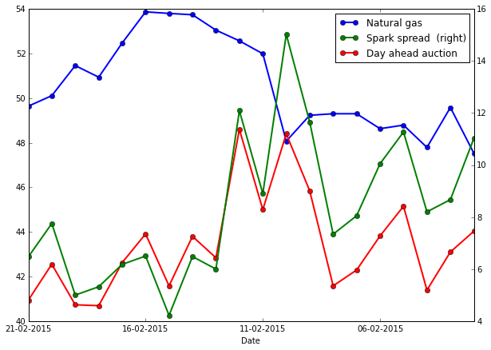

```python
df.plot(secondary_y=['Spark spread '], figsize=(10,7), style='o-', linewidth=2);
```

## Is this old or new school?

### BMRA system prices

```python
from IPython.display import HTML
HTML('<iframe src=http://www.bmreports.com/bsp/SystemPricesHistoric.htm width=1060 height=550></iframe>')
```

[interactive chart not shown]

### Simple trick

Use the CSV button, behind it there is an equivalent to a form submission with the date we need, like so

```python
date = datetime(2015, 2, 1)

url = "http://www.bmreports.com/bsp/SystemPrices.php?pT=SYSPRICE&dT={}&submit=Go"
url = url.format(date.strftime('%Y-%m-%d'))
url
```

```
'http://www.bmreports.com/bsp/SystemPrices.php?pT=SYSPRICE&dT=2015-02-01&submit=Go'
```

```python
r = requests.get(url)
r.content
```

```
'\n<!DOCTYPE html PUBLIC "-//W3C//DTD XHTML 1.0 Transitional//EN" "http://www.w3.org/TR/xhtml1/DTD/xhtml1-transitional.dtd">\n\n<html xmlns="http://www.w3.org/1999/xhtml">\n\t\n\t<head>\n\t<meta http-equiv="Content-Type" content="text/html; charset=utf-8" />\n\t<link rel="stylesheet" href="css/Syste…
```

A simple request is not enough to get the data! However, selenium works:

```python
chromebin = r'C:\Program Files (x86)\Google\Chrome\Application\chromedriver.exe'
driver = webdriver.Chrome(executable_path=chromebin)
driver.get(url)
time.sleep(10)
html = driver.page_source
driver.quit()
```

```python
soup = BeautifulSoup(html)
ssoup = soup('table', {'class': 'tablesorter'})[0]
columns = [h.string.split('(')[0] for h in ssoup('thead')[0]('th')]

try:
    idx = [i for i in range(len(columns)) if name in columns[i]][0]
    columns[idx] = name+'(GBP/MWh)'
except IndexError:
    pass

data = []
for line in ssoup('tbody')[0]('tr'):
    tds = line('td')
    res = []
    for t in tds:
       res.append(t.string)
    data.append(res)
df = pd.DataFrame(data, columns=columns)
df.head()
```

|  | Settlement Date | Period | SSP | SBP | BD | PDC | NIV | SPA | BPA | RP | RPRV | OV | BV | TOV | TBV | ASV | ABV | TASV | TABV | Links to Underlying Data |
| --- | --- | --- | --- | --- | --- | --- | --- | --- | --- | --- | --- | --- | --- | --- | --- | --- | --- | --- | --- | --- |
| 0 | 2015-02-01 | 1 | 28.07474 | 32.90000 | F | F | -107.4434 | 0.00 | 0.00 | None | None | 1198.358 | -705.802 | 1198.358 | -598.358 | -600.000 | 0.000 | -600.000 | 0.000 | None |
| 1 | 2015-02-01 | 2 | 28.00000 | 32.60000 | F | F | -116.2666 | 0.00 | 0.00 | None | None | 1184.500 | -701.662 | 1184.500 | -585.395 | -600.000 | 0.000 | -600.000 | 0.000 | None |
| 2 | 2015-02-01 | 3 | 28.08128 | 31.15000 | F | F | -209.8587 | 0.00 | 0.00 | None | None | 1184.548 | -795.425 | 1184.548 | -585.567 | -600.000 | 0.000 | -600.000 | 0.000 | None |
| 3 | 2015-02-01 | 4 | 25.39055 | 30.92000 | F | F | -448.9670 | 0.00 | 0.00 | None | None | 1184.500 | -1033.467 | 1184.500 | -746.967 | -600.000 | 0.000 | -437.533 | 0.000 | None |
| 4 | 2015-02-01 | 5 | 27.68321 | 27.68321 | F | G | -231.3694 | 0.00 | 0.00 | None | None | 1198.883 | -830.596 | 1198.883 | -608.446 | -600.000 | 0.000 | -590.781 | 0.000 | None |

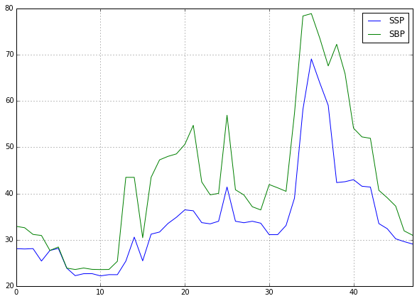

```python
df[['SSP','SBP']].astype(float).plot(figsize=(10,7));
```

## To wrap up

- there is lots of interesting data out there
- python has some very powerful libraries to srape and parse data (urllib2, requests, selenium, BeautifulSoup...)
- but with great power comes great responsibility
- bots shouldn't query too often
- spamming